# DriverTypeColour

DanielaFontes

Thursday, April 23, 2015

iCO2 March Campaign 2014

# Europe data

```
##              driver_id   played_time       driver_type    colour
##  '100000521594761': 1   Min.   :    56.0   Crazy : 3   Blue  :10
##  '100000537154403': 1   1st Qu.:   360.2   Eco   :22   Gray  : 4
##  '100000927423210': 1   Median :   553.5   Gentle: 2   Green : 9
##  '100001012418673': 1   Mean   :  6865.8   Normal:25   Red   :23
##  '100001053594687': 1   3rd Qu.:   982.2               White : 3
##  '100001337360580': 1   Max.   :129265.0               Yellow: 3
##  (Other)          :46
##  driver_type_ordered   is_yellow           is_red          is_blue
##  Eco   :22           Min.   :0.00000   Min.   :0.0000   Min.   :0.0000
##  Gentle: 2           1st Qu.:0.00000   1st Qu.:0.0000   1st Qu.:0.0000
##  Normal:25           Median :0.00000   Median :0.0000   Median :0.0000
##  Crazy : 3           Mean   :0.05769   Mean   :0.4423   Mean   :0.1923
##                      3rd Qu.:0.00000   3rd Qu.:1.0000   3rd Qu.:0.0000
##                      Max.   :1.00000   Max.   :1.0000   Max.   :1.0000
##
##     is_green         is_gray
##  Min.   :0.0000   Min.   :0.00000
##  1st Qu.:0.0000   1st Qu.:0.00000
##  Median :0.0000   Median :0.00000
##  Mean   :0.1731   Mean   :0.07692
##  3rd Qu.:0.0000   3rd Qu.:0.00000
##  Max.   :1.0000   Max.   :1.00000
##
```

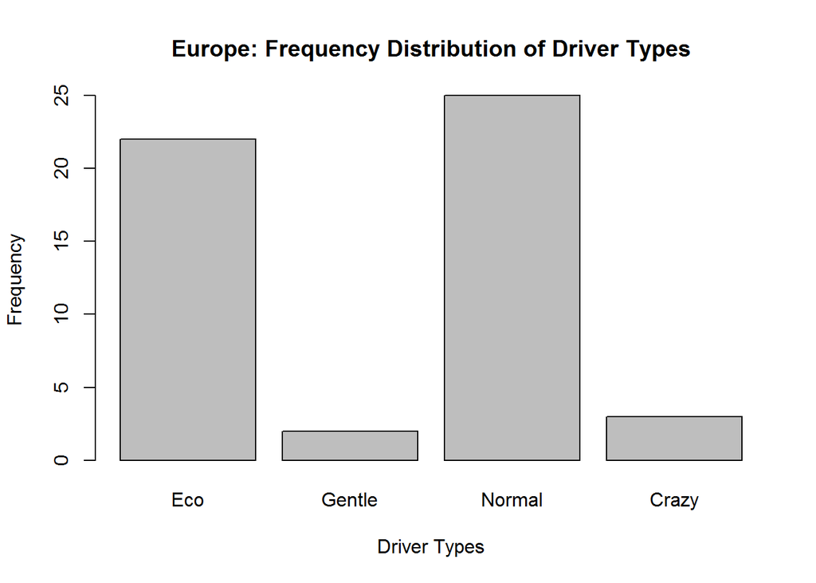

## Joint Probability distribution

```
##         driver_type
## colour        Crazy        Eco     Gentle     Normal
##   Blue   0.00000000 0.05769231 0.00000000 0.13461538
##   Gray   0.01923077 0.01923077 0.00000000 0.03846154
##   Green  0.00000000 0.09615385 0.01923077 0.05769231
##   Red    0.03846154 0.19230769 0.01923077 0.19230769
##   White  0.00000000 0.00000000 0.00000000 0.05769231
##   Yellow 0.00000000 0.05769231 0.00000000 0.00000000
```

# Asia data

```
##              driver_id   played_time       driver_type    colour
##  '100000060739145': 1   Min.   :    74.0   Crazy : 8   Blue  : 6
##  '100000078420374': 1   1st Qu.:   379.0   Eco   :18   Gray  : 9
##  '100000559217160': 1   Median :   654.5   Gentle: 4   Green :14
##  '100000570667797': 1   Mean   : 32605.8   Normal:22   Red   :17
##  '100001160195542': 1   3rd Qu.:  1402.8               White : 2
##  '100001269102653': 1   Max.   :792005.0               Yellow: 4
##  (Other)          :46
##  driver_type_ordered   is_yellow           is_red          is_blue
##  Eco   :18           Min.   :0.00000   Min.   :0.0000   Min.   :0.0000
##  Gentle: 4           1st Qu.:0.00000   1st Qu.:0.0000   1st Qu.:0.0000
##  Normal:22           Median :0.00000   Median :0.0000   Median :0.0000
##  Crazy : 8           Mean   :0.07692   Mean   :0.3269   Mean   :0.1154
##                      3rd Qu.:0.00000   3rd Qu.:1.0000   3rd Qu.:0.0000
##                      Max.   :1.00000   Max.   :1.0000   Max.   :1.0000
##
##     is_green         is_gray
##  Min.   :0.0000   Min.   :0.0000
##  1st Qu.:0.0000   1st Qu.:0.0000
##  Median :0.0000   Median :0.0000
##  Mean   :0.2692   Mean   :0.1731
##  3rd Qu.:1.0000   3rd Qu.:0.0000
##  Max.   :1.0000   Max.   :1.0000
##
```

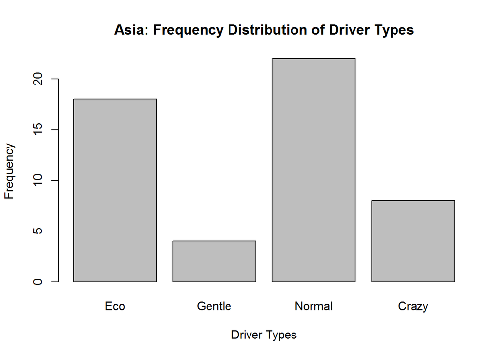

## Joint Probability distribution

```
##         driver_type
## colour        Crazy        Eco     Gentle     Normal
##   Blue   0.05769231 0.01923077 0.00000000 0.03846154
##   Gray   0.00000000 0.05769231 0.03846154 0.07692308
##   Green  0.05769231 0.11538462 0.01923077 0.07692308
##   Red    0.01923077 0.09615385 0.01923077 0.19230769
##   White  0.00000000 0.00000000 0.00000000 0.03846154
##   Yellow 0.01923077 0.05769231 0.00000000 0.00000000
```

# USA data

```
##              driver_id      colour    played_time     driver_type
##  '100000030049306':  1   Blue  :27   Min.   :    40   Crazy : 1
##  '100000077230654':  1   Gray  :12   1st Qu.:   258   Eco   :97
##  '100000151504569':  1   Green :28   Median :   444   Gentle: 5
##  '100000167037187':  1   Red   :41   Mean   :  6435   Normal:10
##  '100000180077862':  1   White : 3   3rd Qu.:   899
##  '100000200118106':  1   Yellow: 2   Max.   :173625
##  (Other)          :107
##  driver_type_ordered   is_yellow          is_red          is_blue
##  Eco   :97           Min.   :0.0000   Min.   :0.0000   Min.   :0.0000
##  Gentle: 5           1st Qu.:0.0000   1st Qu.:0.0000   1st Qu.:0.0000
##  Normal:10           Median :0.0000   Median :0.0000   Median :0.0000
##  Crazy : 1           Mean   :0.0177   Mean   :0.3628   Mean   :0.2389
##                      3rd Qu.:0.0000   3rd Qu.:1.0000   3rd Qu.:0.0000
##                      Max.   :1.0000   Max.   :1.0000   Max.   :1.0000
##
##     is_green         is_gray
##  Min.   :0.0000   Min.   :0.0000
##  1st Qu.:0.0000   1st Qu.:0.0000
##  Median :0.0000   Median :0.0000
##  Mean   :0.2478   Mean   :0.1062
##  3rd Qu.:0.0000   3rd Qu.:0.0000
##  Max.   :1.0000   Max.   :1.0000
##
```

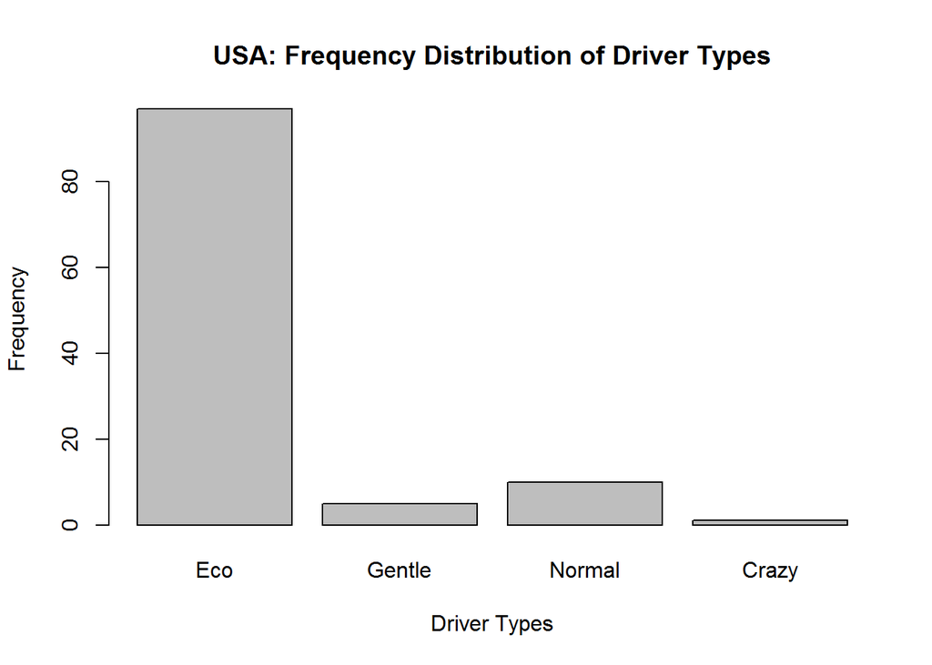

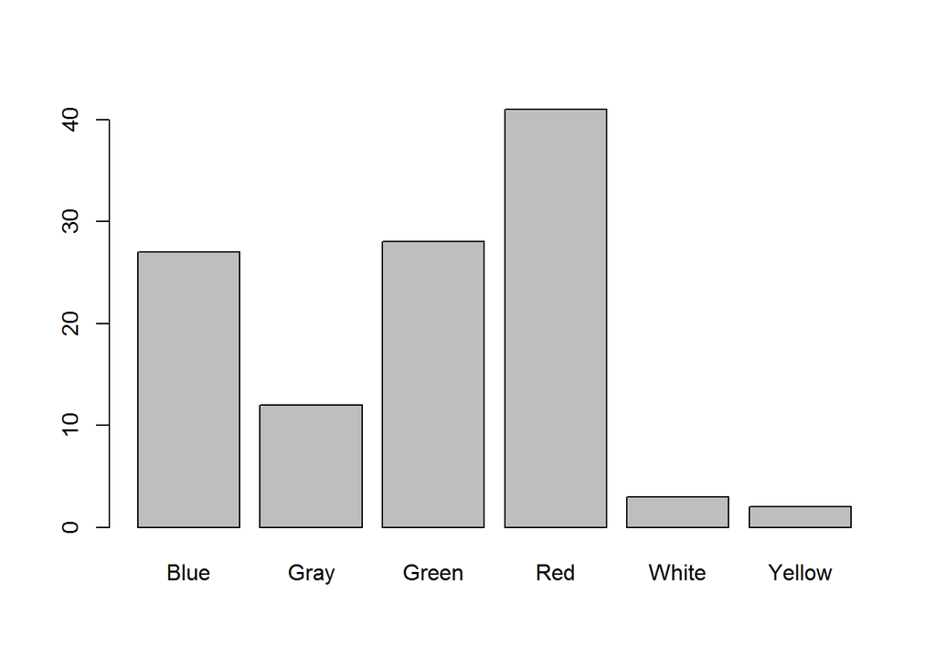

## Joint Probability distribution

```
##         driver_type_ordered
## colour           Eco      Gentle      Normal       Crazy
##   Blue   0.203539823 0.008849558 0.026548673 0.000000000
##   Gray   0.097345133 0.000000000 0.008849558 0.000000000
##   Green  0.212389381 0.008849558 0.026548673 0.000000000
##   Red    0.300884956 0.026548673 0.026548673 0.008849558
##   White  0.026548673 0.000000000 0.000000000 0.000000000
##   Yellow 0.017699115 0.000000000 0.000000000 0.000000000
```

# Correlation between painting car “Red” and being “Eco-unfriendly”.

“Eco-unfriendliness is characterized by the levels/ranks”Eco" < “Gentle” < “Normal” < “Crazy”. We are using Kendall correlation coefficient because we are interested in the relationship between the ranks of the variables.

```
Europe data set [1] 0.00275346
```

```
US data set [1] 0.0590441
```

```
Asia data set [1] 0.002721
```

# Correlation between painting car “Blue” and being “Eco-unfriendly”.

“Eco-unfriendliness is characterized by the levels/ranks”Eco" < “Gentle” < “Normal” < “Crazy”. We are using Kendall correlation coefficient because we are interested in the relationship between the ranks of the variables.

```
Europe data set [1] 0.09889218
```

```
US data set [1] 0.0108376
```

```
Asia data set [1] 0.2516941
```

# Correlation between painting car “Yellow” and being “Eco-unfriendly”.

“Eco-unfriendliness is characterized by the levels/ranks”Eco" < “Gentle” < “Normal” < “Crazy”. We are using Kendall correlation coefficient because we are interested in the relationship between the ranks of the variables.

```
Europe data set [1] -0.2639342
```

```
US data set [1] -0.0534095
```

```
Asia data set [1] -0.1389103
```

# Correlation between painting car “Green” and being “Eco-unfriendly”.

“Eco-unfriendliness is characterized by the levels/ranks”Eco" < “Gentle” < “Normal” < “Crazy”. We are using Kendall correlation coefficient because we are interested in the relationship between the ranks of the variables.

```
Europe data set [1] -0.168089
```

```
US data set [1] 0.002548746
```

```
Asia data set [1] -0.04028648
```

# Correlation between painting car “Gray” and being “Eco-unfriendly”.

“Eco-unfriendliness is characterized by the levels/ranks”Eco" < “Gentle” < “Normal” < “Crazy”. We are using Kendall correlation coefficient because we are interested in the relationship between the ranks of the variables.

```
Europe data set [1] 0.1565276
```

```
US data set [1] -0.05357411
```

```
Asia data set [1] -0.1180863
```